# Broad-scale correlations between traits suggest parent-offspring conflict is universal across class Mammalia

Benjamin Downer-Bartholomew

Carter Rouleau

Farida Samad-zada

Saanmugi Shanmugadasan

```r
library(lme4)
```

```r
library(ggplot2)
library(ggthemes)
library(tidyverse)
library(broom)


devtools::load_all(".")
```

```
## Loading eeb430.2017.Python
```

```r
team_theme <- function() {list(

  theme(axis.line = element_line(color = "black"),
        text = element_text(size = 8, family = "Times"),
        panel.background = element_rect(fill = 'white', colour = 'black'),
        panel.grid.minor = element_blank(),
        panel.grid.major = element_blank(),
        plot.title = element_text(colour =  "black", size = 14, hjust = 0.5),
        legend.text = element_text(size = 12, family = "Times")),
  scale_colour_colorblind())
}
```

## Abstract

Parent-offspring conflict theory states that individuals behave in a manner that optimizes their overall fitness and reproductive success, yet this optimum doesn’t always align between the parent and the offspring leading to conflict (Marshall & Uller 2007). Most studies have focused on studying parent-offspring conflict in mammalian species, but these studies have focused on specific orders or species and thus their conclusions cannot be generalized for how parents and offspring’s act in mammals as a whole. In this study, we examined parent-offspring conflict by generating a linear mixed effects model and plotting the relationship between the number of offspring produced per a year with weaning time (months), age of first reproduction, and the maximum life span of the mother across 7 mammalian orders, *Artiodactyla*, *Carnivora*, *Cetacea*, *Insectivora*, *Lagomorpha*, *Primates*, and *Rodentia*. We found that there is a negative correlation between the number of offspring produced per a year with weaning time, age of first reproduction, and maximum life span for all 7 mammalian orders.

## Introduction

### Parent-Offspring Conflict

In the animal kingdom, individuals should behave in a manner that maximizes their overall fitness and reproductive success. This is most often manifested in the form of behaviors meant to maximize the fitness of every offspring an individual produces over the course of their life (Marshall & Uller 2007). Resources are distributed evenly across all of a parent’s offspring because a parent is equally related to each of their offspring, and thus should attempt to ensure the fitness of each offspring is maximized (Hamilton 1964). Conversely, from the perspctive of the offspring, each individual is more related to itself than any of its siblings, and thus each offspring should want more resources allocated to it than a parent is willing to provide (Trivers 1974).

Robert Trivers discussed the dynamics of parent-offspring conflict in terms of cost-benefit ratios. At birth, the interests of the parent and offspring align, because the offspring is capable of little on its own. Thus, it is in the parent’s interest to provide as much care as possible to ensure the offspring’s survival. However, as the offspring grows, the cost of providing resources increases for the parent, and the benefit decreases, since the offspring is somewhat able to feed itself. From the parent’s perspective, care should be terminated when its costs and benefits are equal. From the offspring’s perspective, care should be terminated when its costs are double its benefits. Conflict arises when the costs are between one and two times as great as the benefits (Trivers 1974).

Both parents and offspring have been shown to utilize manipulative tactics when conflicts arise. In squamates, mothers have been shown to actively attempt to increase egg incubation temperatures in order to accelerate hatching and increase body size at hatch. The larger offspring are more precocial, and faster hatching times mean that mothers do not have to spend as long caring for their current set of offspring (Olsson & Shine 1997). There is extensive evidence of offspring using manipulative tactics, particularly in birds. Chicks are widely known to beg for food from their parents, particularly when parents decrease the amount of care they provide (Harper 1986).

### Mammalian Life Histories

The present study utilizes a large published dataset to attempt to quantify evidence of parent-offspring conflict in mammals. The largest trade-off in the general mammalian life history involves the cost of reproduction. Investment in current reproductive efforts results in costs paid in both survival and potential future reproduction (Stearns 1989). Specific mammalian life histories can be described by the fast-slow continuum hypothesis, which places species along a continuum based on their reproductive rate and generation time. The fast end of the continuum is populated by species that mature early with high reproductive rates and short generation times, while the slow end contains species that take longer to mature, have lower reproductive rates and longer generation times (Oli 2004).

Oli (2004) utilized published life history data from 138 mammal populations to attempt to place species along his fast-slow continuum, and found that species were evenly distributed across the entire continuum. 29 species were categorized as fast, 31 were slow, and 29 were placed centrally on the continuum. Species on either end of the continuum had a number of shared characters. The majority of fast species had relatively small body size, high fertility rates, and low survival rates. Contrarily, slow species tended to have larger body size, lower fertility rates, and higher survival rates.

Species at both ends of Oli’s continuum have had their reproductive life histories examined. Moore *et al.* (2016) examined reproductive fitness in golden-mantled ground squirrels, a species that falls at the fast end of Oli’s continuum. They found evidence of a trade-off between delayed age of first reproduction and offspring survival rate. By delaying their age of first reproduction, parents experienced a decrease in individual fitness, but an increase in offspring survival rate. Offspring born to parents who became reproductively active earlier had a lower survival rate, but the parents had a higher individual fitness. Hadley *et al.* (2007) studied reproductive costs in Weddell seals, a slow species on Oli’s continuum. These seals are intermittent breeders, and can wait several years between breeding events. Reproductive activity was shown to be associated with a decrease in individual survival. Breeding individuals were also less likely than non-breeding individuals to breed in the next season, suggesting that the costs of reproduction are quite high.

### Mammalian Gestation

The majority of investment into offspring by to placental animals occurs during gestation. There is evidence of trade-offs with respect to gestation period length in mammals. In many bat species, there is a positive correlation between gestation period length and neonate size (Kurta & Kunz 1987). Individual fitness of the parents is forfeit as gestation time increases, due to survival costs while pregnant. Thus, there is potential for parent-offspring conflict as investment into gestation increases.

Gestation time has also been shown to vary depending on whether placental neonates are altricial or precocial. Altricial young tend to require a higher level of maternal investment for a given gestation period than precocial young. Because of this, gestation periods in species that produce altricial young are shorter (Martin & MacLarnon 1985). Production of altricial young is often associated with an increase in overall reproductive output. A species that produces altricial young will tend to have a higher reproductive rate than a similar species that produces precocial young, due to the increased costs associated with the rearing of precocial young (Hennemann 1984).

There is evidence of a trade-off between maternal investment in gestation and lactation. It has been observed that the cost of gestation is less than that of lactation (Gittleman & Thompson 1988). This is a potential source of parent-offspring conflict, given that altricial neonates require a relatively long lactation period (Hennemann 1984). There is a high degree of variation in the relative allocation of resources to either gestation or lactation across mammals, so inferences made about energetic expenditure by the mother or parent-offspring conflict over lactation period length must consider the species’ life history. Furthermore, there is evidence that many trends related to gestation could be inaccurate due to the ubiquity of neonate body mass as a measure of development during gestation. Sacher and Staffeldt (1974) argue that neonate brain mass, rather than body mass, should be used to describe trends related to gestation. The brain has the slowest development rate of any organ, and the growth of other bodily tissues is limited by, but not necessarily always equal to, the rate of brain growth.

### Post-Birth Resource Allocation

The majority of parent-offspring conflict in mammals occurs post-birth. At this point in neonate development, the parent has already invested a sigificant amount of resources into their offspring, and will be attempting to decrease the amount of care they provide (Trivers 1974). As neonates grow, their energetic needs increase, and until they are effectively able to source their own nutrients, they will become increasingly dependent on their mother for nutrition via milk. Free-ranging dogs have a well-studied weaning conflict. Pups nurse from birth and weaning begins in their seventh week. At this point, the mother will refuse to nurse. It was observed that as the pups grew, their nursing attempts became more frequent, and the mothers’ attempts to initiate nursing became less frequent (Paul & Bhadra 2017).

There is evidence that female mammals will attempt to increase their milk production to accommodate larger litter sizes. Female house mice were observed to increase both the volume and nutrient content of their milk when they birthed larger litters (Kounig *et al.* 1988). However, this increase was not indefinite. The larger the litter got, the smaller the percent increase in nutrient content was. Neonates from larger litters had lower post-weaning body mass than those from smaller litters. This is evidence that parent-offspring conflict is likely more prevalent in larger litters, because it is more difficult for neonates to obtain the nutrients they require to not have a post-weaning fitness disadvantage when compared to neonates from smaller litters.

Maternal size has a significant effect on lactation performance. In marmosets, it has been observed that smaller mothers produce milk with lower nutrient and fat content than larger mothers (Tardif *et al.* 2001). Smaller mothers also nurse their offspring less frequently. Smaller mothers are also more likely to lose further weight and less likely to be fertile in subsequent breeding seasons. This is grounds for parent-offspring conflict, because mothers are very clearly sacrificing future reproductive success to care for current offspring as well as individual health and fitness.

### Objectives

The present study aims to demonstrate that instances of parent-offspring conflict that are described in a small amount of mammalian species are likely to occur across a wide range of mammalian taxa. By presenting correlations between mammalian reproductive traits, we will provide evidence for parent-offspring conflict as a phenomenon that is universal within class Mammalia. Many existing studies have described isolated cases of parent-offspring conflict in mammals, but, to our knowledge, no study has examined the dynamics of parent-offspring conflict in mammals as a complete class. While the present work is not obervation-based, we will not be able to claim a causal relationship between the traits we correlate. The results we provide should be used as evidence that parent-offspring conflict is likely a universal phenomenon in mammals. Species or genus level studies should be continued in order to prove causal relationships between the traits we have correlated.

## Methods

### Dataset Description

The dataset utilized in this study was made available by Morgan S.K. Ernest from the Department of Biology, University of New Mexico, Albuquerque, New Mexico, 87131 USA. The dataset is a compilation of general life history characteristics of 17 placental nonvolant mammalian orders. The data was obtained from various literature sources starting from 1998 and is currently ongoing. These past literature sources have studied species from various trophic levels, and habitats, therefore in this dataset the life history characteristics were averaged to get rid of minor environmental/niche specific differences. The dataset represents all placental nonvolant mammalian orders including terrestrial and aquatic mammals, expect for the *Chiroptera* (bats) order for a total of 17 orders. The 17 orders and the number of species represented in each order in the dataset are *Artiodactyla* (161 species), *Carnivora* (197 species), *Cetacea* (55 species), *Dermoptera* (2 species), *Hydracoidea* (4 species), *Insectivora* (91 species), *Lagomorpha* (42 species), *Macroscelidea* (10 species), *Perissodactyla* (15 species), *Pholidota* (7 species), *Primates* (156 species), *Proboscidea* (2 species), *Rodentia* (665 species), *Scandentia* (7 species), *Sirenia* (5 species), *Tubulidentata* (1 species), and *Xenarthra* (20 species). The 9 life history characteristics represented in the dataset are: maximum lifespan (months) which is the oldest age recorded for a member of that species (male or female), age of first reproduction (months) which is the average age when a females first breeds, gestation time (months) which is the average length of time the fetus is in the womb, weaning age (months) which is the average age an offspring begins eating solid food , weaning mass (grams) which is the average mass of an offspring when they begins eating solid food, litter size which is the average number of offspring birthed in single liter, litters per a year which is the average number of litters birthed in a 12 month period, newborn mass (grams) which is the average weight of a newborn taken within 12 hours after birth, and adult body mass (grams) which is the average weight of non-pregnant adult females.

### Data Analysis

Despite the fact that the original dataset contained 17 orders, we narrowed down the dataset, by including only the orders, where number of observations was more than 30. Hence, only Rodentia, Cetacea, Insectivora, Carnivora, Lagomorpha, Primates, Artiodactyla were used in the analysis. Additionally, we log transformed our data in order to be able to implement linear regression into our analysis.

All the modeling and statistical analyses were conducted using R version 3.4.1 (R Core Team 2017). We analyzed the number of offspring per year, as well as the maximum life span, weaning age and the age of first reproduction using generalized linear model and mixed effects model . Glm (https://cran.r-project.org/web/packages/glm2/glm2.pdf) and lme4 (https://cran.r-project.org/web/packages/lme4/lme4.pdf) R packages were used for modeling. Log transformed values of weaning age, maximum lifespan and age of first reproduction were used as fixed effects. Additionally, in the mixed effects model, orders were used as a random effect factor in order to account for life-history variations, as well as size differences between orders. We used the linear model because when log transformed our data showed the same trend for the three parameters. Additionally, we decided to use the mixed effects model because in our dataset the values are not independent: observations of mammals in the same order are correlated.

We compared the two models using Akaike Information Criterion (AIC) to see if additional parameters significantly improved the fit of the model (Akaike 1973). AIC penalizes the model for additional parameters, such that with increased number of parameters, the penalty is also increasing. So, the best fit is the one with the lowest score: i.e. with the least amount of information lost in a model, compared to the real data (Akaike 1973). Since mixed effects model was a better fit than the generalized linear model, in our results and discussion sections, we only focus on the former.

## Results

### Weaning Time

According to the prediction of mixed-effects linear model, there is a negative relationship between the weaning age and the number of offspring across all orders (Fig. 1). Moreover, using orders as random effects significantly improves the model fit, compared to using generalized linear model, as indicated by the lower AIC value (Table 1). The overall linear trend across all orders appears to be negative for the weaning-number of offspring relationship. However, Rodentia, Insectivora and Primates show the most negative relationship with slopes being higher than 0.6 (Table 2). Additionally, despite all trends being negative there is order-specific variation in both the number of offspring, and weaning age (Fig. 1). Larger mammals tend to have less offspring and delay the weaning time, whereas small mammals produce more offspring, and wean fairly early (Fig. 1).

```r
fit <- lmer(log.oy ~ log.wm + (log.wm | order), data = mammals_sub)
summary(fit)
```

```
## Linear mixed model fit by REML ['lmerMod']
## Formula: log.oy ~ log.wm + (log.wm | order)
##    Data: mammals_sub
##
## REML criterion at convergence: 930.1
##
## Scaled residuals:
##     Min      1Q  Median      3Q     Max
## -3.3252 -0.5630 -0.0068  0.5674  3.1843
##
## Random effects:
##  Groups   Name        Variance Std.Dev. Corr
##  order    (Intercept) 0.38662  0.6218
##           log.wm      0.02339  0.1529   -0.49
##  Residual             0.31243  0.5590
## Number of obs: 533, groups:  order, 7
##
## Fixed effects:
##             Estimate Std. Error t value
## (Intercept)  1.50287    0.24570   6.117
## log.wm      -0.63388    0.07769  -8.159
##
## Correlation of Fixed Effects:
##        (Intr)
## log.wm -0.481
```

```r
lme4::ranef(fit)
```

```
## $order
##              (Intercept)      log.wm
## Artiodactyla  -0.3577862  0.02524210
## Carnivora     -0.2656723  0.22310309
## Cetacea       -0.8940070  0.03853831
## Insectivora    0.4096360 -0.07353584
## Lagomorpha     0.7911287 -0.03236692
## Primates      -0.2267442 -0.05473396
## Rodentia       0.5434450 -0.12624678
```

```r
tidy(fit, conf.int = TRUE)
```

```
##                           term   estimate  std.error statistic  conf.low
## 1                  (Intercept)  1.5028709 0.24570240  6.116631  1.021303
## 2                       log.wm -0.6338820 0.07768867 -8.159260 -0.786149
## 3         sd_(Intercept).order  0.6217858         NA        NA        NA
## 4              sd_log.wm.order  0.1529476         NA        NA        NA
## 5 cor_(Intercept).log.wm.order -0.4861032         NA        NA        NA
## 6      sd_Observation.Residual  0.5589585         NA        NA        NA
##   conf.high    group
## 1  1.984439    fixed
## 2 -0.481615    fixed
## 3        NA    order
## 4        NA    order
## 5        NA    order
## 6        NA Residual
```

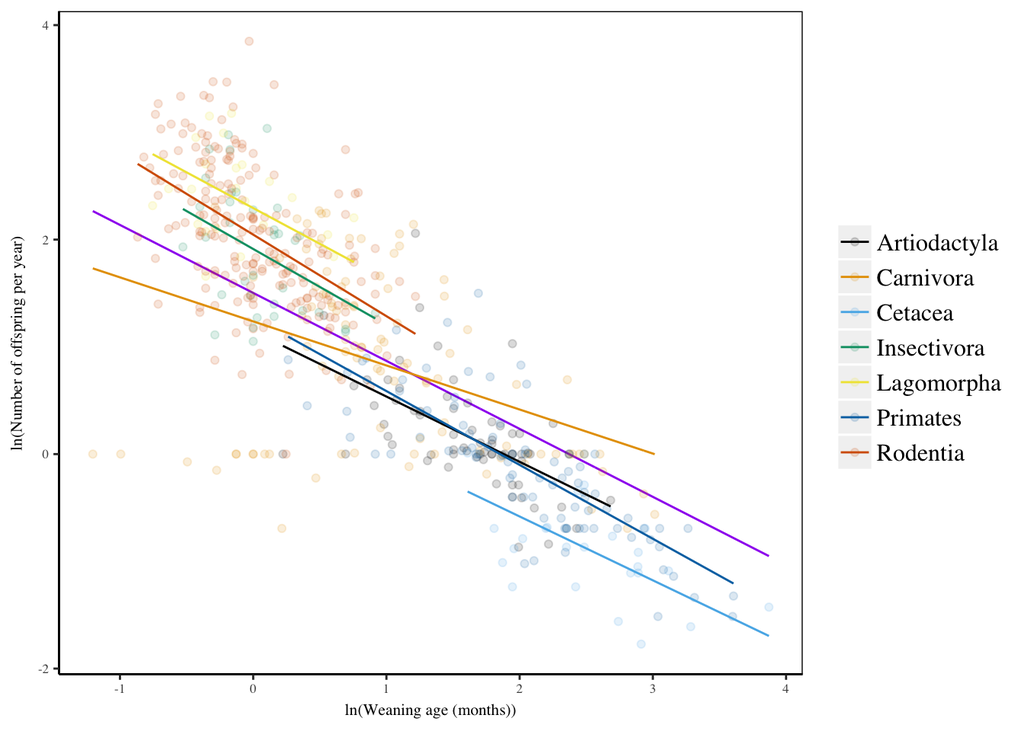

Figure 1: Figure 1 displays the linear mixed effects model of the ln of the Weaning age versus the ln of Offspring per year. The x-axis is the ln transformed age of weaning in months. The y-axis is the ln transformed number of offspring produced on average over a year. The purple line is the general linear for all of the data points. The other 7 lines are the trends for the individal orders. The dots represent the raw data points.

```r
broom::augment(fit) %>%
    ggplot(aes(x = log.wm, y = .fixed)) +
    geom_line(color = "Purple") +
    geom_point(aes(x = log.wm, y = log.oy, color = order), alpha = 0.15) +
    geom_line(aes(y = .fitted, color = order)) +
    team_theme() + ylab("ln(Number of offspring per year)") + xlab("ln(Weaning age (months))") + theme(legend.title=element_blank())
```

### Age of First Reproduction

```r
b <- lmer(log.oy ~ log.AFR + (log.AFR | order), data=mammals_sub)
summary(b)
```

```
## Linear mixed model fit by REML ['lmerMod']
## Formula: log.oy ~ log.AFR + (log.AFR | order)
##    Data: mammals_sub
##
## REML criterion at convergence: 795.1
##
## Scaled residuals:
##     Min      1Q  Median      3Q     Max
## -3.2495 -0.6341 -0.0162  0.6380  3.2195
##
## Random effects:
##  Groups   Name        Variance Std.Dev. Corr
##  order    (Intercept) 0.3342   0.5781
##           log.AFR     0.0812   0.2850   -0.47
##  Residual             0.2319   0.4816
## Number of obs: 542, groups:  order, 7
##
## Fixed effects:
##             Estimate Std. Error t value
## (Intercept)   2.7737     0.2513  11.035
## log.AFR      -0.6037     0.1145  -5.275
##
## Correlation of Fixed Effects:
##         (Intr)
## log.AFR -0.537
```

```r
lme4::ranef(b)
```

```
## $order
##              (Intercept)     log.AFR
## Artiodactyla  -0.5846331 -0.07162499
## Carnivora      0.8566171 -0.29501976
## Cetacea       -0.5015507 -0.11174519
## Insectivora   -0.1528481  0.25183326
## Lagomorpha    -0.1058527  0.42672130
## Primates       0.3179899 -0.28274597
## Rodentia       0.1702776  0.08258135
```

```r
tidy(b, conf.int=TRUE)
```

```
##                            term   estimate std.error statistic   conf.low
## 1                   (Intercept)  2.7736904 0.2513456 11.035367  2.2810622
## 2                       log.AFR -0.6037416 0.1144590 -5.274739 -0.8280772
## 3          sd_(Intercept).order  0.5781290        NA        NA         NA
## 4              sd_log.AFR.order  0.2849531        NA        NA         NA
## 5 cor_(Intercept).log.AFR.order -0.4660865        NA        NA         NA
## 6       sd_Observation.Residual  0.4816015        NA        NA         NA
##   conf.high    group
## 1  3.266319    fixed
## 2 -0.379406    fixed
## 3        NA    order
## 4        NA    order
## 5        NA    order
## 6        NA Residual
```

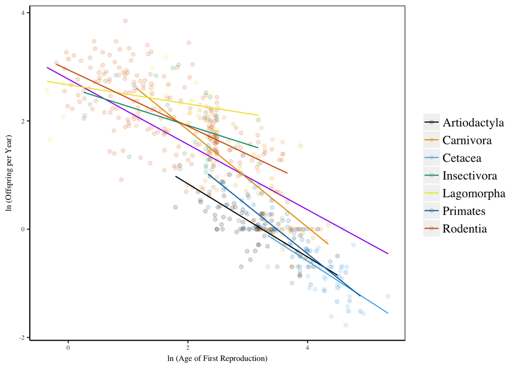

Figure 2: Figure 2 displays the linear mixed effects model of the ln of Age of First Reproduction versus the ln of Offspring per year. The x-axis is the ln transformed age of first reproduction in months. The y-axis is the ln transformed number of offspring produced on average over a year. The purple line is the general linear for all of the data points. The other 7 lines are the trends for the individal orders. The dots represent the raw data points.

```r
broom::augment(b) %>%
    ggplot(aes(x=log.AFR, y=.fixed)) +
    geom_line( color = 'Purple') +
    geom_point(aes(x=log.AFR, y=log.oy, color = order), alpha = 0.15) +
    geom_line(aes(y=.fitted, color=order))+
    labs(x = "ln (Age of First Reproduction)", y = "ln (Offspring per Year)")+
  team_theme()+
    theme(legend.title=element_blank())
```

### Maximum Lifespan

```r
c <- lmer(log.oy ~ log.ml + (log.ml | order), data = mammals_sub)
summary(c)
```

```
## Linear mixed model fit by REML ['lmerMod']
## Formula: log.oy ~ log.ml + (log.ml | order)
##    Data: mammals_sub
##
## REML criterion at convergence: 702.4
##
## Scaled residuals:
##     Min      1Q  Median      3Q     Max
## -3.0919 -0.6647 -0.1098  0.5699  3.4378
##
## Random effects:
##  Groups   Name        Variance Std.Dev. Corr
##  order    (Intercept) 4.0825   2.0205
##           log.ml      0.1382   0.3717   -0.91
##  Residual             0.3151   0.5613
## Number of obs: 391, groups:  order, 7
##
## Fixed effects:
##             Estimate Std. Error t value
## (Intercept)   4.4842     0.8628   5.197
## log.ml       -0.6788     0.1608  -4.220
##
## Correlation of Fixed Effects:
##        (Intr)
## log.ml -0.926
```

```r
lme4::ranef(c)
```

```
## $order
##              (Intercept)      log.ml
## Artiodactyla -0.44425339 -0.02095551
## Carnivora     3.11736307 -0.55291115
## Cetacea      -2.58895848  0.24081831
## Insectivora  -0.82068466  0.23992633
## Lagomorpha   -0.01862677  0.21776353
## Primates      1.25562998 -0.33380489
## Rodentia     -0.50046974  0.20916338
```

```r
library(broom)
tidy(c, conf.int = TRUE)
```

```
##                           term   estimate std.error statistic   conf.low
## 1                  (Intercept)  4.4841948 0.8627797  5.197381  2.7931778
## 2                       log.ml -0.6787725 0.1608278 -4.220491 -0.9939893
## 3         sd_(Intercept).order  2.0205140        NA        NA         NA
## 4              sd_log.ml.order  0.3717246        NA        NA         NA
## 5 cor_(Intercept).log.ml.order -0.9085303        NA        NA         NA
## 6      sd_Observation.Residual  0.5612992        NA        NA         NA
##    conf.high    group
## 1  6.1752119    fixed
## 2 -0.3635557    fixed
## 3         NA    order
## 4         NA    order
## 5         NA    order
## 6         NA Residual
```

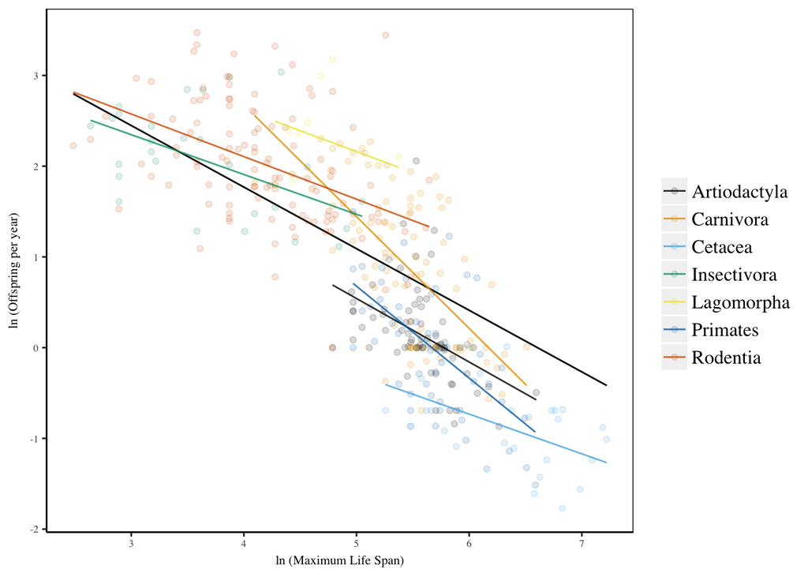

Figure 3: Relationship between the lon transformed number of offspring a mother produces per a year during her life span as predicted by the linear mixed-effects model of 7 mammalian orders. The long black line represents the overall trend where each coloured line represents the trend for each mammalian order. The dots represent the raw data points.

```r
broom::augment(c) %>%
    ggplot(aes(x = log.ml, y = .fixed)) +
    geom_line() +
    geom_point(aes(x = log.ml, y = log.oy, color = order), alpha = 0.15) +
    geom_line(aes(y = .fitted, color = order), alpha = 0.8) +
    team_theme()+
    theme(legend.title = element_blank())+
    labs(x="ln (Maximum Life Span)", y="ln (Offspring per year)")
```

Table 1: AIC values

```r
AIC <- matrix(c((942.1),(1028.6),
                (807.1),(1047.6),
                (714.4),(837.0)), ncol = 2, byrow = TRUE)
colnames(AIC) <- c("AIC Values", "Base Values")
rownames(AIC) <- c("Weaning", "Age of First Reproduction", "Max Life Span")
AIC <- as.table(AIC)
AIC
```

```
##                           AIC Values Base Values
## Weaning                        942.1      1028.6
## Age of First Reproduction      807.1      1047.6
## Max Life Span                  714.4       837.0
```

Table 2: Linear regression slopes for the 3 plots

```r
Order <- matrix(c((-0.6086379),(-0.6037+-0.07162499),(-0.02095551+-0.6788),
                  (-0.41077695),(-0.6037+-0.29501976), (-0.55291115+-0.6788),
                  (-0.59534164), (-0.6037+-0.11174519), (0.24081831+-0.6788),
                  (-0.70741582),(-0.6037+ 0.25183326),(0.23992633+-0.6788),
                  (-0.66624698),(-0.6037+0.42672130),(0.21776353+-0.6788),
                  (-0.68861395), (-0.6037+-0.28274597), (-0.33380489+-0.6788),
                  (-0.76012677), (-0.6037+0.08258135), (0.20916338+-0.6788)), ncol=3, byrow=TRUE)
colnames(Order) <- c("Slope for Weaning", "Slope for Age of First Reprodution", "Slope for Max Life Span")
rownames(Order) <- c("Artiodactyla", "Carnivora", "Cetacea", "Insectivora", "Lagomorpha", "Primates", "Rodentia")
Order <- as.table(Order)
Order
```

```
##              Slope for Weaning Slope for Age of First Reprodution
## Artiodactyla        -0.6086379                         -0.6753250
## Carnivora           -0.4107769                         -0.8987198
## Cetacea             -0.5953416                         -0.7154452
## Insectivora         -0.7074158                         -0.3518667
## Lagomorpha          -0.6662470                         -0.1769787
## Primates            -0.6886140                         -0.8864460
## Rodentia            -0.7601268                         -0.5211187
##              Slope for Max Life Span
## Artiodactyla              -0.6997555
## Carnivora                 -1.2317111
## Cetacea                   -0.4379817
## Insectivora               -0.4388737
## Lagomorpha                -0.4610365
## Primates                  -1.0126049
## Rodentia                  -0.4696366
```

## Discussion

### Age of First Reproduction

These results indicate that mammal species that reproduce latter in life will produce fewer offspring per year. Mammals that reporduce latter in life would be catagorized as slow under Oli’s continum, while mammals that reproduce earlier on would be catagorized as fast by Oli (Oli 2004). ‘Fast’ mammals are ones that mature earlier on in their life history, and this early maturation would lead to them reproducing earlier on as well. This earlier reproductive maturation is associated with a decrease in individual offspring fitness (Moore *et al.* 2016). Increasing the total number of offspring produced per year could help to reduce the costs of having low individual offspring survivorship associated with earlier reporduction. ‘Slow’ mammals instead take a longer amount of time to reach an age where they will be able to successfully reproduce and their offspring will have a greater chance of surviving (Moore *et al.* 2016). The addition of orders in the model, shows that there is a large amount of variation in age of first reproduction and offspring per year between species within the orders. This can be seen by the slopes for each of lines of the individual orders in Table 2. The most negative slopes are those of Carnivora and Primates. These two groups have the greatest variation in both of the two traits being looked at. Most of the model lines for the orders are separated into two clusters, with Carnivora being the only order to pass through both regions. Species within carnivora fall on both the fast and slow ends of Oli’s continum, with some producing many offspring each year early in life, with other species reproducing latter on. Although the results show that there is a correlation between the number of offspring produced per year and the age of first reproduction, no comment can be made on if there is any causality. It can not be stated that the timing of reproductive maturation alone determines the number of offspring produced. Thus, this subject could still use further research into it.

### Maximum Lifespan

The present study has shown a negative correlation between the number of offspring produced per year and parental maximum lifespan in mammals (Figure 3). This correlation is expected as a result of parent offspring conflict. A longer maximum lifespan is associated with a longer period of reproductive activity (McNamara *et al.* 2009). Given that a parent should behave in a manner that maximizes the fitness of all of their offspring, both present and future (Hamilton 1964), parents who are reproductively active for a longer time should reproduce their per year offspring production and care, given the increased costs of a longer reproductively active lifespan. Parents who have longer reproductively active periods will want to allocate a higher proportion of their available resources towards future reproduction than parents who have a short reproductively active period (Trivers 1974). When a parent decides to re-allocate resources away from current reproduction, they are likely to reduce both the amount of care provided to each offspring and the number of offspring produced. As reproductively active lifespan increases, there is the potential for intense parent-offspring conflict. Each offspring a mother produces will come with a cost, which will be manifested in a lower potential future reproductive ability. When reproductive lifespan is long, costs to future reproductive ability are undesirable, because a parent has a high number of potential future reproductive events, and compromising these will result in a lower fitness for a high proportion of their offspring. As such, parental care for individual offspring should be limited, because the cost-benefit ratio for each offspring will increase more quickly. Potential parent-offspring conflict could arise sooner, and is likely to be more intense, given that there is more at stake for the parent (Trivers 1974). In mammals with shorter reproductively active lifespans, there is still the potential for parent-offspring conflict, but the conflict is likely to be more driven by sibling-sibling competition. Parents with shorter reproductively active lifespans will always be caring for a higher proportion of their entire pool of potential offspring than parents with longer reproductively active periods, and thus the cost of providing care will not be as high, given that they are not sacrificing the fitness of as many potential future offspring. However, because the number of offspring these parents produce in each reproductive event is higher, the energetic costs of care can become significant. Thus, parents are likely limiting the care provided to each current offspring, which is the basis for parent-offspring conflict.

## Literature Cited

- Akaike,H. (1973). Information theory and an extension of the maximum likelihood principle. Proc. 2nd Inter. Symposium on Information Theory, 267-281, Budapest.
- Clutton-Brock T.H. 1984. Reproductive effort and terminal investment in iteroparous animals. *American Naturalist* 123: 212-229.
- Collinge N.E. 1987. Weaning variability in semi-free-ranging Japanese macaques (*Macaca fuscata*). *Folia Primatoogical* (Basel). 1987;48(3-4):137-50.
- Gittleman J, Thompson S. 1988. Energy allocation in mammalian reproduction. *American Zoology* 28(3): 863-875.
- Gomendio M. 1990 The influence of maternal rank and infant sex on maternal investment trends in rhesus macaques: birth sex ratio, inter-birth intervals and suckling patterns. *Behavioral Ecology and Sociobiology* 27:365–375.
- Hadley GL, Rotella JJ, Garrott RA. 2007. Evaluation of reproductive costs for Weddell seals in Erebus Bay, Antarctica. *Journal of Animal Ecology* 76(3): 448-458.
- Hamilton WD. 1964. The genetical evolution of social behavior. I. *J. Theoret. Biol.* 7: 1-16.
- Harper AB. 1986. The evolution of begging: Sibling competition and parent-offspring conflict. *The American Naturalist* 128(1): 99-114.
- Hedrich H.J., and Bullock G.R. 2004. The laboratory mice. *Elsevier Academic Press*.
- Hennemann WW. 1984. Intrinsic rates of natural increase of altricial and precocial eutherian mammals: the potential price of precociality. *Oikos* 43(3): 363-368.
- Kounig B, Riester J, Markl H. 1988. Maternal care in house mice (*Mus musculus*): II. The energy cost of lactation as a function of litter size. *Journal of Zoology* 216(2): 195-210.
- Kurta A, Kunz T. 1987. Size of bats at birth and maternal investment during pregnancy. *Zoological Symposium* 57: 79-106.
- Maestripieri D. and Hoffmann C.L. 2012. Behavior and social dynamics of rhesus macaques on Cayo Santiago. Developments in Primatology: Progress and Prospects. *Springer Science+Business Media*, LLC.
- Malmkvist J, Sorensen D.D., Larsen T., Palme R., and Hansen S.W. 2016. Weaning and separation stress: maternal motivation decreases with litter age and litter size in farmed mink. *Applied Animal Behaviour Science* 181:152-159.
- Marshall DJ, Uller T. 2007. When is a maternal effect adaptive? *Oikos* 116: 1957-1963.
- Martin R, MacLarnon A. 1985. Gestation period, neonatal size and maternal investment in placental mammals. *Nature* 313(17): 220-223.
- McNamara JM, Houston AI, Barta Z, Scheuerlein A, Fromhage L. 2009. Deterioration, death and the evolution of reproductive constraint in late life. *Proc. R. Soc. B Biol 276(1675): 4061-4066.
- Moore JF, Wells CP, Van Vuren DH, Oli MK. 2016. Who pays? intra- vs inter-generational costs of reproduction. *Ecosphere* 7(2): e01236.
- Oli M. 2004. The fast-slow continuum and mammalian life-history patterns: an empirical evaluation. *Basic and Applied Ecology* 5(5): 449-463.
- Olsson M, Shine R. 1997. The seasonal timing of oviposition in sand lizards (*Lacerta agilis*): Why earlier clutches are better. *Evolution* 52: 1861-1864.
- Paul M, Bhadra A. 2017. Selfish pups: weaning conflict and milk theft in free-ranging dogs. *PLoS One* 12(2): e0170590.
- Sacher G, Staffeldt E. 1974. Relation of gestation time to brain weight for placental mammals: implications for the theory of vertebrate growth. *The American Naturalist* 108(963): 593-615.
- Sergeant, D E. 1973. Biology of white whales (*Delphinapterus leuras*) in western Hudson Bay. *Journal of the Fisheries of the Research Board on Canada* 30:1065-1090.
- Stearns SC. 1989. Trade-offs in life history evolution. *Functional Ecology* 3(3): 259-268.
- Tardif SD, Power M, Oftedal OT, Power RA, Layne DG. 2001. Lactation, maternal behavior and infant growth in common marmoset monkeys (*Callithrix jacchus*): effects of maternal size and litter size. *Behavioral Ecology and Sociobiology* 51(1): 17-25.
- Trivers RL. 1974. Parent-offspring conflict. *American Zoologist* 14(1): 249-264.

## Supplementary Figures

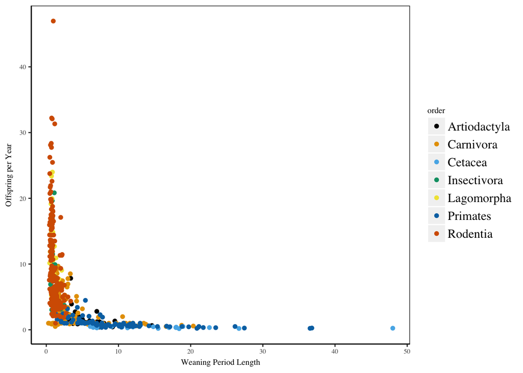

Figure S4: Non-transformed relationship between weaning age and number of offspring per year

```r
mammals_sub %>%
    ggplot(aes(x=weaning_month, y=offspring.year)) +
    geom_point(aes(color = order)) +
    team_theme() +
    labs(x="Weaning Period Length", y="Offspring per Year")
```

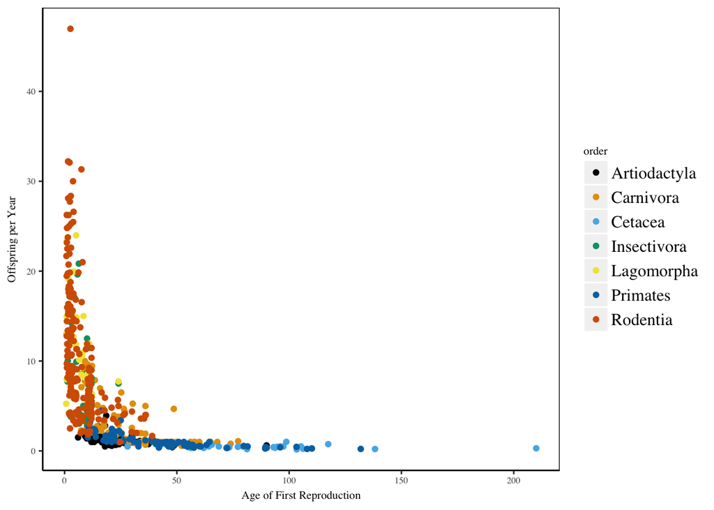

Figure S5: Non-transformed relationhip betwen age of first reproduction and number of offsrping per year

```r
mammals_sub %>%
    ggplot(aes(x=AFR_mo, y=offspring.year)) +
    geom_point(aes(color = order)) +
    team_theme() +
    labs(x="Age of First Reproduction", y="Offspring per Year")
```

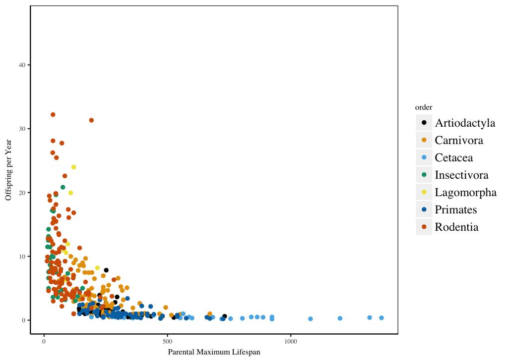

Figure S6: Non-transformed relationship between maximum life span and number of offsrping per year

```r
mammals_sub %>%
    ggplot(aes(x=max_life_month, y=offspring.year)) +
    geom_point(aes(color = order)) +
    team_theme() +
    labs(x="Parental Maximum Lifespan", y="Offspring per Year")
```